# assign4

**Assignment 4 - Linear Regression Using Tidymodels**

Packages required: *tidyverse*, *tidymodels*.

```r
#install.packages("esquisse")
library(esquisse)
library(ggplot2)
```

Here we will use the Tidymodels framework for building the linear regression models.

As usual, the deliverable is a rendered HTML document containing your work and any requested commentary. It is helpful if you clearly label each task.

Read the dataset in the “player_per_game.csv” file into a data frame called “bball”.

```r
bball = read_csv("player_per_game.csv")
```

**Q1** Examine the structure and summary of the dataset and then complete the following cleaning tasks:

```r
summary(bball)
```

```
     name               pos                 age          team_id
 Length:20593       Length:20593       Min.   :18.00   Length:20593
 Class :character   Class :character   1st Qu.:24.00   Class :character
 Mode  :character   Mode  :character   Median :26.00   Mode  :character
                                       Mean   :26.77
                                       3rd Qu.:29.00
                                       Max.   :44.00

       g            mp_per_g        fg_per_g        fga_per_g
 Min.   : 1.00   Min.   : 0.00   Min.   : 0.000   Min.   : 0.000
 1st Qu.:25.00   1st Qu.:11.40   1st Qu.: 1.300   1st Qu.: 3.100
 Median :53.00   Median :19.00   Median : 2.500   Median : 5.600
 Mean   :48.74   Mean   :19.82   Mean   : 3.048   Mean   : 6.743
 3rd Qu.:74.00   3rd Qu.:28.10   3rd Qu.: 4.300   3rd Qu.: 9.500
 Max.   :85.00   Max.   :44.50   Max.   :13.400   Max.   :27.800

     fg_pct         fg3_per_g        fg3a_per_g        fg3_pct
 Min.   :0.0000   Min.   :0.0000   Min.   : 0.000   Min.   :0.000
 1st Qu.:0.4000   1st Qu.:0.0000   1st Qu.: 0.000   1st Qu.:0.133
 Median :0.4430   Median :0.1000   Median : 0.500   Median :0.301
 Mean   :0.4381   Mean   :0.4298   Mean   : 1.254   Mean   :0.257
 3rd Qu.:0.4860   3rd Qu.:0.7000   3rd Qu.: 2.100   3rd Qu.:0.365
 Max.   :1.0000   Max.   :5.1000   Max.   :13.200   Max.   :1.000
 NA's   :99                                         NA's   :3574
   fg2_per_g        fg2a_per_g        fg2_pct         efg_pct
 Min.   : 0.000   Min.   : 0.000   Min.   :0.000   Min.   :0.0000
 1st Qu.: 1.000   1st Qu.: 2.400   1st Qu.:0.425   1st Qu.:0.4350
 Median : 2.000   Median : 4.400   Median :0.469   Median :0.4780
 Mean   : 2.618   Mean   : 5.489   Mean   :0.461   Mean   :0.4678
 3rd Qu.: 3.700   3rd Qu.: 7.700   3rd Qu.:0.507   3rd Qu.:0.5150
 Max.   :13.200   Max.   :27.000   Max.   :1.000   Max.   :1.5000
                                   NA's   :155     NA's   :99
    ft_per_g        fta_per_g          ft_pct         orb_per_g
 Min.   : 0.000   Min.   : 0.000   Min.   :0.0000   Min.   :0.000
 1st Qu.: 0.500   1st Qu.: 0.800   1st Qu.:0.6610   1st Qu.:0.400
 Median : 1.100   Median : 1.500   Median :0.7500   Median :0.800
 Mean   : 1.517   Mean   : 2.034   Mean   :0.7233   Mean   :1.002
 3rd Qu.: 2.100   3rd Qu.: 2.800   3rd Qu.:0.8150   3rd Qu.:1.400
 Max.   :10.300   Max.   :13.100   Max.   :1.0000   Max.   :6.900
                                   NA's   :876
```

[output cut: 8 more lines]

```
   blk_per_g        tov_per_g        pf_per_g       pts_per_g
 Min.   :0.0000   Min.   :0.000   Min.   :0.000   Min.   : 0.000
 1st Qu.:0.1000   1st Qu.:0.600   1st Qu.:1.300   1st Qu.: 3.400
 Median :0.2000   Median :1.000   Median :1.900   Median : 6.500
 Mean   :0.4024   Mean   :1.228   Mean   :1.902   Mean   : 8.041
 3rd Qu.:0.5000   3rd Qu.:1.700   3rd Qu.:2.500   3rd Qu.:11.500
 Max.   :6.0000   Max.   :5.700   Max.   :6.000   Max.   :37.100

      bpm
 Min.   :-1000.000
 1st Qu.:   -3.700
 Median :   -1.600
 Mean   :   -1.981
 3rd Qu.:    0.400
 Max.   :  242.200
```

```r
str(bball)
```

```
spc_tbl_ [20,593 × 29] (S3: spec_tbl_df/tbl_df/tbl/data.frame)
 $ name      : chr [1:20593] "Kareem Abdul-Jabbar" "Tom Abernethy" "Tom Abernethy" "Tom Abernethy" ...
 $ pos       : chr [1:20593] "C" "SF" "SF" "SF" ...
 $ age       : num [1:20593] 33 26 26 26 26 22 32 32 23 26 ...
 $ team_id   : chr [1:20593] "LAL" "TOT" "GSW" "IND" ...
 $ g         : num [1:20593] 80 39 10 29 75 22 80 47 82 82 ...
 $ mp_per_g  : num [1:20593] 37.2 7.6 3.9 8.9 27.4 12.5 35.3 12.9 31 31.8 ...
 $ fg_per_g  : num [1:20593] 10.5 0.6 0.1 0.8 6.1 1 4.8 0.9 5.4 6.7 ...
 $ fga_per_g : num [1:20593] 18.2 1.5 0.3 1.9 11.6 3 9.6 2 10.8 14.5 ...
 $ fg_pct    : num [1:20593] 0.574 0.424 0.333 0.429 0.526 0.343 0.499 0.473 0.499 0.463 ...
 $ fg3_per_g : num [1:20593] 0 0 0 0 0 0 0 0 0 0.1 ...
 $ fg3a_per_g: num [1:20593] 0 0 0 0 0 0 0.1 0 0 0.4 ...
 $ fg3_pct   : num [1:20593] 0 0 NA 0 NA 0 0 NA 0.5 0.219 ...
 $ fg2_per_g : num [1:20593] 10.5 0.6 0.1 0.8 6.1 1 4.8 0.9 5.4 6.6 ...
 $ fg2a_per_g: num [1:20593] 18.2 1.5 0.3 1.9 11.6 3 9.5 2 10.8 14.1 ...
 $ fg2_pct   : num [1:20593] 0.574 0.431 0.333 0.436 0.526 0.348 0.505 0.473 0.499 0.47 ...
 $ efg_pct   : num [1:20593] 0.574 0.424 0.333 0.429 0.526 0.343 0.499 0.473 0.5 0.466 ...
 $ ft_per_g  : num [1:20593] 5.3 0.3 0.2 0.4 2.7 0.6 4.3 0.3 3.1 2 ...
 $ fta_per_g : num [1:20593] 6.9 0.6 0.3 0.7 3.5 1 5.2 0.4 4.4 2.4 ...
 $ ft_pct    : num [1:20593] 0.766 0.591 0.667 0.579 0.768 0.591 0.816 0.7 0.709 0.847 ...
 $ orb_per_g : num [1:20593] 2.5 0.5 0.1 0.7 2.1 0.9 0.5 0.7 2.3 2 ...
 $ drb_per_g : num [1:20593] 7.8 0.7 0.7 0.7 5.2 2.1 1.8 1.6 5.1 5 ...
 $ trb_per_g : num [1:20593] 10.3 1.2 0.8 1.4 7.3 3 2.2 2.3 7.4 7.1 ...
 $ ast_per_g : num [1:20593] 3.4 0.5 0.1 0.6 4.6 1.1 7.7 1.1 1.2 2.4 ...
 $ stl_per_g : num [1:20593] 0.7 0.2 0.1 0.2 1.4 0.2 0.9 0.3 0.9 1.4 ...
 $ blk_per_g : num [1:20593] 2.9 0.1 0 0.1 0.9 0.4 0.2 0.2 1.7 0.5 ...
 $ tov_per_g : num [1:20593] 3.1 0.2 0.2 0.2 3 1 3.3 0.7 2.7 1.4 ...
 $ pf_per_g  : num [1:20593] 3.1 0.9 0.5 1 3 2.3 2.5 1.8 4 2.4 ...
 $ pts_per_g : num [1:20593] 26.2 1.6 0.4 2 14.9 2.7 13.8 2.2 14 15.5 ...
 $ bpm       : num [1:20593] 6.1 -2.6 -4.4 -2.4 5.1 -5.6 -0.1 -2.5 -1.1 2.2 ...
 - attr(*, "spec")=
  .. cols(
  ..   name = col_character(),
  ..   pos = col_character(),
  ..   age = col_double(),
  ..   team_id = col_character(),
  ..   g = col_double(),
  ..   mp_per_g = col_double(),
  ..   fg_per_g = col_double(),
  ..   fga_per_g = col_double(),
```

[output cut: 8 more lines]

```
  ..   ft_per_g = col_double(),
  ..   fta_per_g = col_double(),
  ..   ft_pct = col_double(),
  ..   orb_per_g = col_double(),
  ..   drb_per_g = col_double(),
  ..   trb_per_g = col_double(),
  ..   ast_per_g = col_double(),
  ..   stl_per_g = col_double(),
  ..   blk_per_g = col_double(),
  ..   tov_per_g = col_double(),
  ..   pf_per_g = col_double(),
  ..   pts_per_g = col_double(),
  ..   bpm = col_double()
  .. )
 - attr(*, "problems")=<externalptr>
```

- Delete the “name”, “team_id”, and “fg3_pct” variables.

  ```r
  bball = bball %>% select(-team_id, - fg3_pct)
  ```

  ```r
  bball = bball %>% select(-name)
  ```

- Convert the “pos” variable to a factor (this variable represents the player’s position).

  ```r
  bball = bball %>% mutate(pos = as_factor(pos))
  ```

  ```r
  bball = bball %>% filter(mp_per_g < 25)
  ```

- Perform row-wise deletion of missingness.

  ```r
  bball = drop_na(bball)
  ```

- There are some odd hybrid positions in the “pos” variable (this variable captures player positions). These hybrid positions all have the “-” character in them. Use the code provided below to filter them out (as part of your data-cleaning code):

  ```r
  bball = bball %>% filter(!str_detect(pos, "-")) %>% droplevels()
  ```

filter(!str_detect(pos, “-”)) %>% droplevels()

**Q2** Create an appropriate plot with “pts_per_g” (on x axis) versus “bpm” (on y axis). Does there appear to be a linear relationship between these variables?

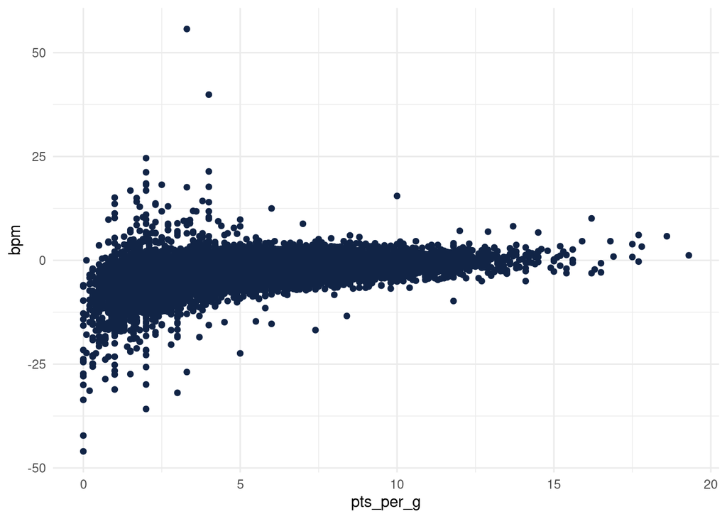

```r
#esquisser()

library(ggplot2)

ggplot(bball) +
 aes(x = pts_per_g, y = bpm) +
 geom_point(colour = "#112446") +
 theme_minimal()
```

- There does not seem to be a strong linear relationship. I say this because as the pts_per_g increases the bpm stays pretty steady or stays the same. You could maybe argue there is a slight positive relationship as you can see the Y start to increase slightly.

**Q3 USING THE TIDYMODEL FRAMEWORK,** create a linear regression model with the “pts_per_g” variable to predict “bpm”. Comment on the linear regression model results. Is this a good model?

```r
bball_recipe = recipe(bpm ~ pts_per_g, data = bball)

lm_model = linear_reg() %>% set_engine("lm")

lm_wflow = workflow() %>% add_model(lm_model) %>% add_recipe(bball_recipe)
```

```r
lm_fit = fit(lm_wflow, bball)
lm_fit
```

```
══ Workflow [trained] ══════════════════════════════════════════════════════════
Preprocessor: Recipe
Model: linear_reg()

── Preprocessor ────────────────────────────────────────────────────────────────
0 Recipe Steps

── Model ───────────────────────────────────────────────────────────────────────

Call:
stats::lm(formula = ..y ~ ., data = data)

Coefficients:
(Intercept)    pts_per_g
    -5.7468       0.5664
```

```r
tidy(lm_fit)
```

```
# A tibble: 2 × 5
  term        estimate std.error statistic p.value
  <chr>          <dbl>     <dbl>     <dbl>   <dbl>
1 (Intercept)   -5.75     0.0609     -94.4       0
2 pts_per_g      0.566    0.0106      53.5       0
```

```r
glance(lm_fit)
```

```
# A tibble: 1 × 12
  r.squared adj.r.squared sigma statistic p.value    df  logLik    AIC    BIC
      <dbl>         <dbl> <dbl>     <dbl>   <dbl> <dbl>   <dbl>  <dbl>  <dbl>
1     0.184         0.184  3.35     2864.       0     1 -33367. 66741. 66763.
# ℹ 3 more variables: deviance <dbl>, df.residual <int>, nobs <int>
```

**Q4** Examine the residuals from your model from Question 3. Recall that the method to extract the residuals from the model is different when you are using the Tidymodels framework! You should develop two plots. One plot should be a histogram of residuals. Ideally, the residuals should appear to be normally-distributed. The other plot should have your predictor (x) variable on the x axis and the residuals on the y axis. Ideally, you should not see a pattern in the residuals when plotted this way. Comment on these two plots.

```r
final_mod = lm_fit %>% extract_fit_parsnip()
final_mod
```

```
parsnip model object


Call:
stats::lm(formula = ..y ~ ., data = data)

Coefficients:
(Intercept)    pts_per_g
    -5.7468       0.5664
```

```r
bball = bball %>% augment(lm_fit,.)
summary(bball)
```

```
 pos            age              g            mp_per_g        fg_per_g
 C :2788   Min.   :18.00   Min.   : 1.00   Min.   : 1.00   Min.   :0.000
 SF:2229   1st Qu.:23.00   1st Qu.:21.00   1st Qu.: 9.70   1st Qu.:1.100
 PF:2771   Median :26.00   Median :43.00   Median :14.40   Median :1.800
 PG:2445   Mean   :26.64   Mean   :42.86   Mean   :14.44   Mean   :1.919
 SG:2466   3rd Qu.:29.00   3rd Qu.:65.00   3rd Qu.:19.40   3rd Qu.:2.600
           Max.   :44.00   Max.   :85.00   Max.   :24.90   Max.   :7.800
   fga_per_g          fg_pct        fg3_per_g        fg3a_per_g
 Min.   : 0.200   Min.   :0.000   Min.   :0.0000   Min.   :0.0000
 1st Qu.: 2.600   1st Qu.:0.386   1st Qu.:0.0000   1st Qu.:0.0000
 Median : 4.000   Median :0.432   Median :0.1000   Median :0.3000
 Mean   : 4.386   Mean   :0.431   Mean   :0.2775   Mean   :0.8411
 3rd Qu.: 5.800   3rd Qu.:0.480   3rd Qu.:0.4000   3rd Qu.:1.4000
 Max.   :16.800   Max.   :1.000   Max.   :2.9000   Max.   :7.4000
   fg2_per_g       fg2a_per_g        fg2_pct          efg_pct
 Min.   :0.000   Min.   : 0.100   Min.   :0.0000   Min.   :0.0000
 1st Qu.:0.900   1st Qu.: 2.000   1st Qu.:0.4090   1st Qu.:0.4180
 Median :1.400   Median : 3.100   Median :0.4580   Median :0.4660
 Mean   :1.641   Mean   : 3.544   Mean   :0.4536   Mean   :0.4591
 3rd Qu.:2.200   3rd Qu.: 4.700   3rd Qu.:0.5010   3rd Qu.:0.5090
 Max.   :7.200   Max.   :15.100   Max.   :1.0000   Max.   :1.0000
    ft_per_g        fta_per_g         ft_pct         orb_per_g
 Min.   :0.0000   Min.   :0.000   Min.   :0.0000   Min.   :0.000
 1st Qu.:0.4000   1st Qu.:0.700   1st Qu.:0.6240   1st Qu.:0.300
 Median :0.8000   Median :1.100   Median :0.7250   Median :0.600
 Mean   :0.9104   Mean   :1.281   Mean   :0.7008   Mean   :0.775
 3rd Qu.:1.2000   3rd Qu.:1.700   3rd Qu.:0.8020   3rd Qu.:1.100
 Max.   :5.9000   Max.   :8.700   Max.   :1.0000   Max.   :4.500
   drb_per_g       trb_per_g        ast_per_g       stl_per_g
 Min.   :0.000   Min.   : 0.000   Min.   :0.000   Min.   :0.0000
 1st Qu.:1.000   1st Qu.: 1.400   1st Qu.:0.400   1st Qu.:0.3000
 Median :1.500   Median : 2.100   Median :0.800   Median :0.4000
 Mean   :1.747   Mean   : 2.519   Mean   :1.144   Mean   :0.4638
 3rd Qu.:2.300   3rd Qu.: 3.400   3rd Qu.:1.500   3rd Qu.:0.6000
 Max.   :8.000   Max.   :11.300   Max.   :9.100   Max.   :2.5000
   blk_per_g        tov_per_g         pf_per_g      pts_per_g
 Min.   :0.0000   Min.   :0.0000   Min.   :0.00   Min.   : 0.000
 1st Qu.:0.1000   1st Qu.:0.5000   1st Qu.:1.10   1st Qu.: 2.800
 Median :0.2000   Median :0.8000   Median :1.60   Median : 4.600
 Mean   :0.3015   Mean   :0.8518   Mean   :1.63   Mean   : 5.023
 3rd Qu.:0.4000   3rd Qu.:1.1000   3rd Qu.:2.10   3rd Qu.: 6.800
 Max.   :6.0000   Max.   :4.0000   Max.   :6.00   Max.   :19.300
      bpm              .pred
 Min.   :-46.000   Min.   :-5.747
 1st Qu.: -4.500   1st Qu.:-4.161
 Median : -2.500   Median :-3.142
 Mean   : -2.902   Mean   :-2.902
 3rd Qu.: -0.900   3rd Qu.:-1.896
 Max.   : 55.700   Max.   : 5.184
```

```r
bball = bball%>% mutate(residuals1 = bpm - .pred)
```

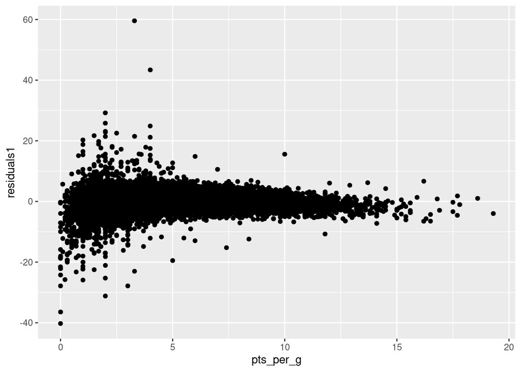

```r
ggplot(bball,aes(x=pts_per_g,y=residuals1)) + geom_point() + geom_jitter(alpha = 0.1)
```

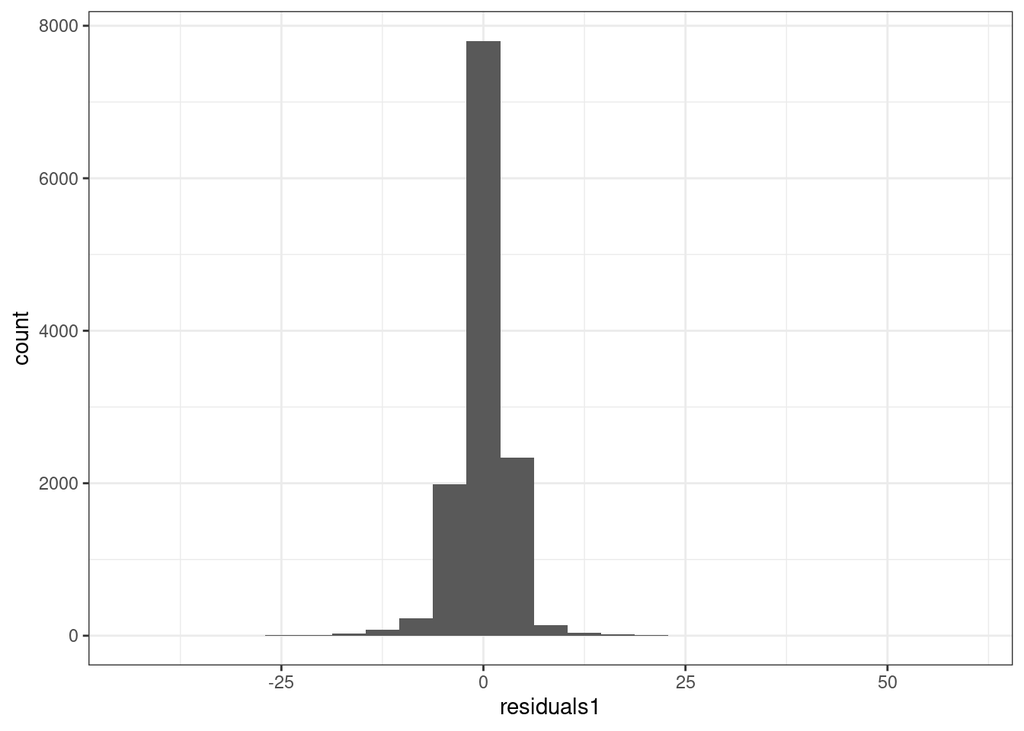

```r
ggplot(bball,aes(x=residuals1)) + geom_histogram(bins=25) + theme_bw()
```

**Q5** Create a linear regression model to predict “bpm” with the following variables (continuing to use the Tidymodels framework): pts_per_g, mp_per_g, efg_pct, ft_pct, and tov_per_g. If you do not know what these variables represent, use Google to find out.

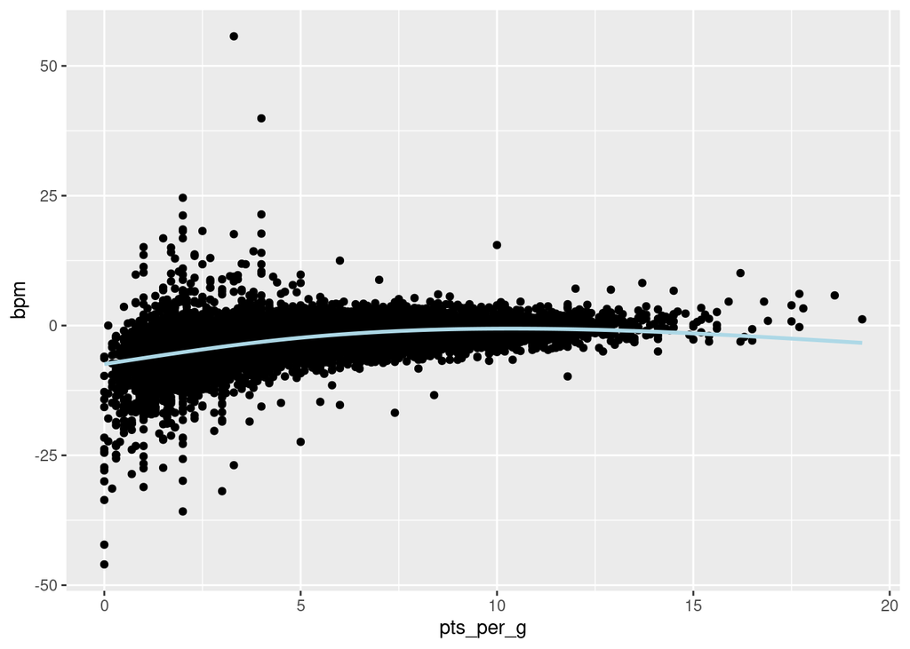

```r
ggplot(bball,aes(x=pts_per_g,y=bpm)) + geom_point() +
  geom_smooth(
      method = lm,
      formula = y ~ ns(x, df = 2),
      color = "lightblue",
      se = FALSE
    )
```

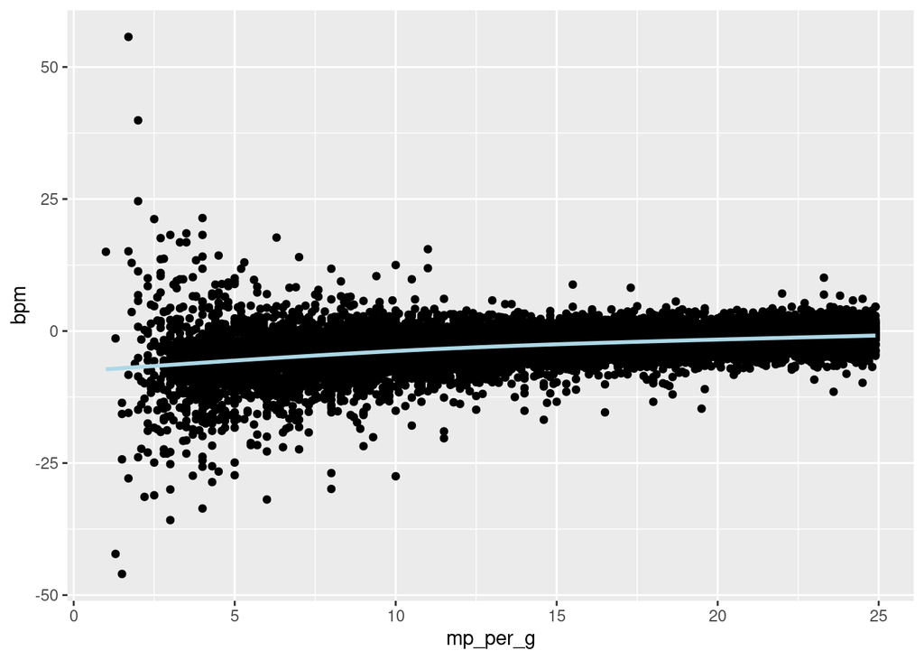

```r
ggplot(bball,aes(x=mp_per_g,y=bpm)) + geom_point() +
  geom_smooth(
      method = lm,
      formula = y ~ ns(x, df = 3),
      color = "lightblue",
      se = FALSE
    )
```

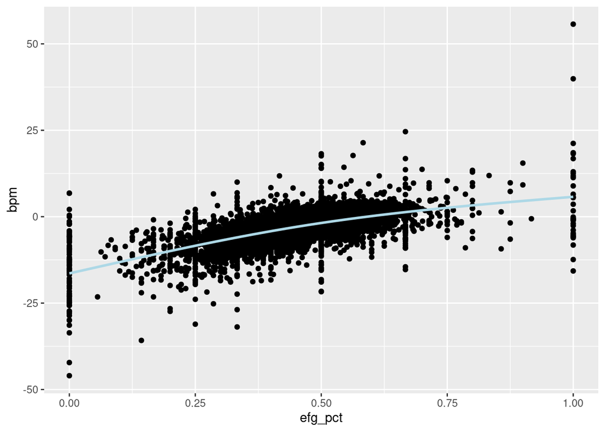

```r
ggplot(bball,aes(x=efg_pct,y=bpm)) + geom_point() +
  geom_smooth(
      method = lm,
      formula = y ~ ns(x, df = 2),
      color = "lightblue",
      se = FALSE
    )
```

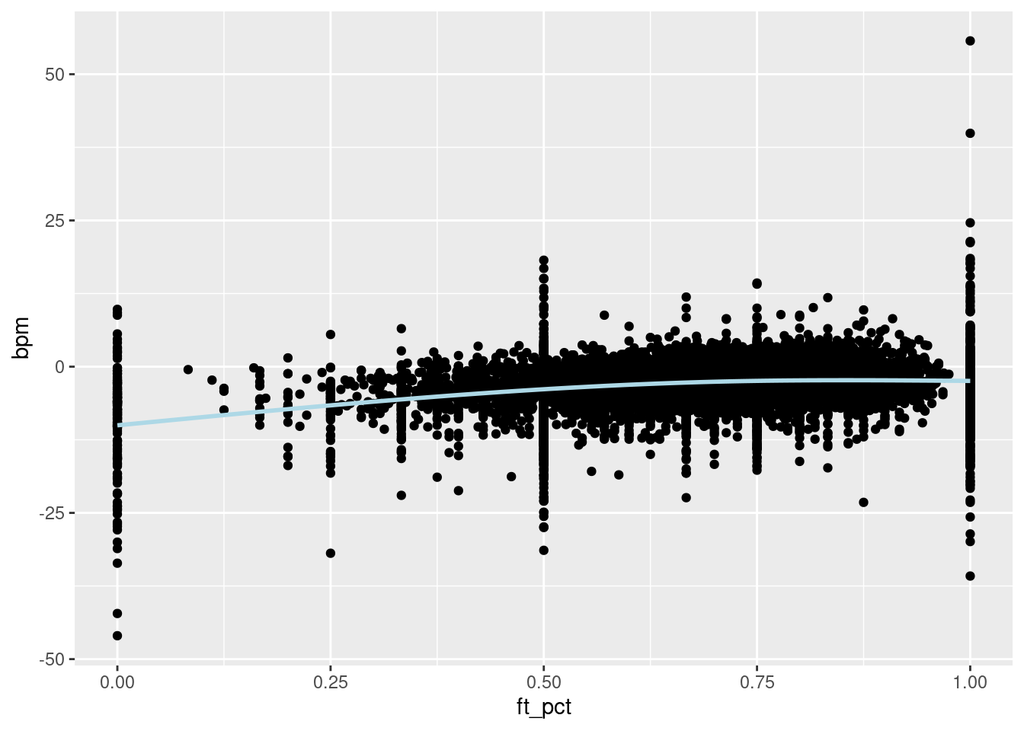

```r
ggplot(bball,aes(x=ft_pct,y=bpm)) + geom_point() +
  geom_smooth(
      method = lm,
      formula = y ~ ns(x, df = 2),
      color = "lightblue",
      se = FALSE
    )
```

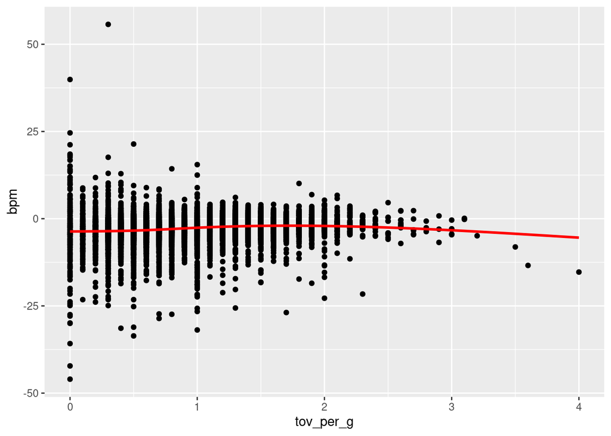

```r
ggplot(bball,aes(x=tov_per_g,y=bpm)) + geom_point() +
  geom_smooth(
      method = lm,
      formula = y ~ ns(x, df = 3),
      color = "red",
      se = FALSE
    )
```

```r
str(bball)
```

```
tibble [12,699 × 28] (S3: tbl_df/tbl/data.frame)
 $ pos       : Factor w/ 5 levels "C","SF","PF",..: 2 2 2 3 1 5 3 4 5 5 ...
 $ age       : num [1:12699] 26 26 26 22 32 24 26 31 23 34 ...
 $ g         : num [1:12699] 39 10 29 22 47 77 28 73 3 52 ...
 $ mp_per_g  : num [1:12699] 7.6 3.9 8.9 12.5 12.9 20.3 11.2 15.2 9.3 22 ...
 $ fg_per_g  : num [1:12699] 0.6 0.1 0.8 1 0.9 5.7 0.9 1.6 1 3.1 ...
 $ fga_per_g : num [1:12699] 1.5 0.3 1.9 3 2 11.7 2.1 4.2 3.3 7.1 ...
 $ fg_pct    : num [1:12699] 0.424 0.333 0.429 0.343 0.473 0.487 0.433 0.386 0.3 0.431 ...
 $ fg3_per_g : num [1:12699] 0 0 0 0 0 0.2 0 0.4 0 0.2 ...
 $ fg3a_per_g: num [1:12699] 0 0 0 0 0 0.7 0.1 1.3 0 0.8 ...
 $ fg2_per_g : num [1:12699] 0.6 0.1 0.8 1 0.9 5.5 0.9 1.2 1 2.9 ...
 $ fg2a_per_g: num [1:12699] 1.5 0.3 1.9 3 2 11 2.1 2.9 3.3 6.4 ...
 $ fg2_pct   : num [1:12699] 0.431 0.333 0.436 0.348 0.473 0.501 0.448 0.408 0.3 0.449 ...
 $ efg_pct   : num [1:12699] 0.424 0.333 0.429 0.343 0.473 0.494 0.433 0.438 0.3 0.446 ...
 $ ft_per_g  : num [1:12699] 0.3 0.2 0.4 0.6 0.3 2.2 1.9 0.9 0.7 1.4 ...
 $ fta_per_g : num [1:12699] 0.6 0.3 0.7 1 0.4 2.6 2.9 1.3 2.7 1.8 ...
 $ ft_pct    : num [1:12699] 0.591 0.667 0.579 0.591 0.7 0.854 0.654 0.684 0.25 0.798 ...
 $ orb_per_g : num [1:12699] 0.5 0.1 0.7 0.9 0.7 0.9 1.2 0.3 0 0.3 ...
 $ drb_per_g : num [1:12699] 0.7 0.7 0.7 2.1 1.6 1.1 2.1 0.7 0.7 1.3 ...
 $ trb_per_g : num [1:12699] 1.2 0.8 1.4 3 2.3 2 3.3 1 0.7 1.6 ...
 $ ast_per_g : num [1:12699] 0.5 0.1 0.6 1.1 1.1 2.5 0.5 2.7 0.7 3.1 ...
 $ stl_per_g : num [1:12699] 0.2 0.1 0.2 0.2 0.3 1.1 0.1 0.6 0.3 0.6 ...
 $ blk_per_g : num [1:12699] 0.1 0 0.1 0.4 0.2 0.1 0.4 0 0 0.2 ...
 $ tov_per_g : num [1:12699] 0.2 0.2 0.2 1 0.7 1.9 1.1 1 0.3 2.1 ...
 $ pf_per_g  : num [1:12699] 0.9 0.5 1 2.3 1.8 1.6 2 1.2 0.7 2.4 ...
 $ pts_per_g : num [1:12699] 1.6 0.4 2 2.7 2.2 13.8 3.8 4.6 2.7 7.8 ...
 $ bpm       : num [1:12699] -2.6 -4.4 -2.4 -5.6 -2.5 1.3 -5 -1.9 -5 -5.2 ...
 $ .pred     : num [1:12699] -4.84 -5.52 -4.61 -4.22 -4.5 ...
 $ residuals1: num [1:12699] 2.24 1.12 2.21 -1.38 2 ...
```

```r
bball_recipe2 =
  recipe(bpm ~., data = bball) %>%
  step_ns(pts_per_g, deg_free = 2) %>%
  step_ns(mp_per_g, deg_free = 3) %>%
  step_ns(efg_pct, deg_free = 2) %>%
  step_ns(ft_pct, deg_free = 2) %>%
  step_ns(tov_per_g, deg_free = 3)
```

```r
lm_model2 =
  linear_reg() %>%
  set_engine("lm")
```

```r
lm_wflow2 =
  workflow() %>%
  add_model(lm_model2) %>%
  add_recipe(bball_recipe2)
```

```r
lm_fit2 = fit(lm_wflow2, data = bball)
```

```r
options(scipen = 999)
tidy(lm_fit2)
```

```
# A tibble: 38 × 5
   term         estimate std.error statistic  p.value
   <chr>           <dbl>     <dbl>     <dbl>    <dbl>
 1 (Intercept) -3.75e-14  6.08e-15    -6.17  7.23e-10
 2 posSF       -2.51e-15  1.72e-16   -14.6   1.05e-47
 3 posPF       -1.60e-15  1.36e-16   -11.8   7.21e-32
 4 posPG       -4.89e-16  2.26e-16    -2.16  3.09e- 2
 5 posSG       -2.68e-15  1.93e-16   -13.9   2.32e-43
 6 age         -7.49e-17  1.08e-17    -6.91  5.17e-12
 7 g            1.85e-17  2.22e-18     8.34  8.10e-17
 8 fg_per_g     5.05e-15  1.48e-15     3.40  6.66e- 4
 9 fga_per_g    7.40e-16  9.53e-16     0.777 4.37e- 1
10 fg_pct      -2.12e-14  3.14e-15    -6.76  1.40e-11
# ℹ 28 more rows
```

```r
glance(lm_fit2)
```

```
# A tibble: 1 × 12
  r.squared adj.r.squared    sigma statistic p.value    df  logLik      AIC
      <dbl>         <dbl>    <dbl>     <dbl>   <dbl> <dbl>   <dbl>    <dbl>
1         1             1 4.72e-15   2.18e32       0    36 400904. -801732.
# ℹ 4 more variables: BIC <dbl>, deviance <dbl>, df.residual <int>, nobs <int>
```

```r
options(scipen = 0)
```

[output not shown]